# Modeling and prediction for movies

## Setup

### Load packages

```r
library(ggplot2)
library(dplyr)
library(statsr)
library(GGally)
```

### Load data

```r
load("movies.Rdata")
```

## Part 1: Data

The data set is comprised of 651 randomly sampled movies produced and released before 2016. Sources for this data set were [Rotten Tomatoes](https://www.rottentomatoes.com/) and [IMDB](https://www.imdb.com/) APIs. Since these sources mostly focusing on English-spoken auditory we need to be very careful to generalizable our conclusion for all world population, but we can be more confident about the US, UK, and other English spoken countries. Also, we need to mention that this data set covert for the most part active internet users. We need to be careful to generalize conclusions for the least active internet users, probably, such as old people and others.

Since we do not have an experiment, but observation study, we can consider the only association, and do not can make causal conclusions.

## Part 2: Research question

Recently, the film market is undergoing serious changes, such companies as Netflix and HBO have brought new ideas / approaches to the market. We are interested in learning what attributes associated with popular moves such as including in moves adult material or very famous actors/actresses and others.

## Part 3: Exploratory data analysis

For the very beginning let’s see rating distributions:

- Rating on IMDB `imdb_rating`

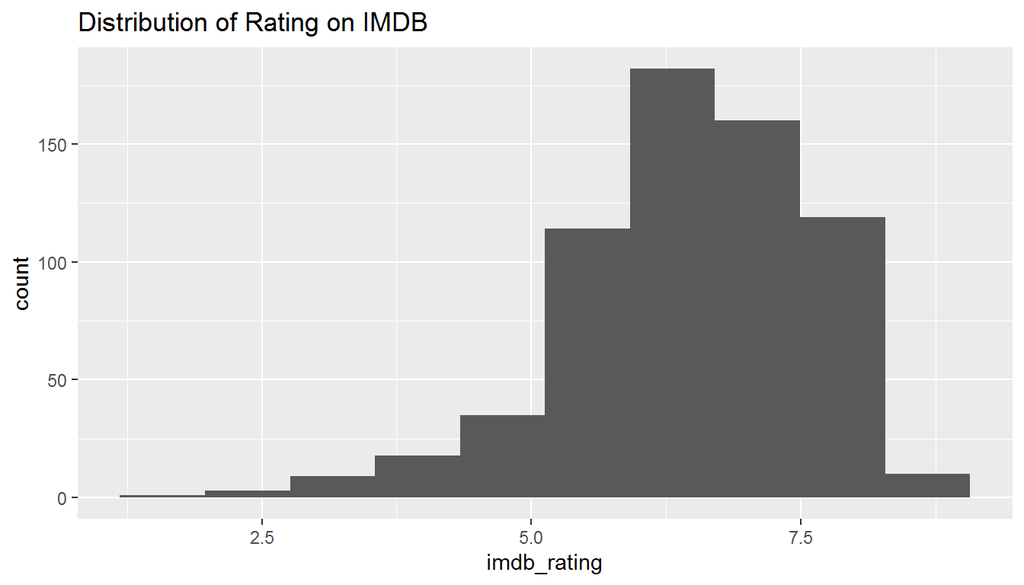

```r
movies %>%
    ggplot(aes(x = imdb_rating)) +
    geom_histogram(bins = 10) +
    ggtitle('Distribution of Rating on IMDB')
```

```r
summary(movies$imdb_rating)
```

```
##    Min. 1st Qu.  Median    Mean 3rd Qu.    Max.
##   1.900   5.900   6.600   6.493   7.300   9.000
```

Distribution of `imdb_rating` is left-skewed with center around 6.6, hence the most appropriate measure of rating going to be median.

- Audience score on Rotten Tomatoes `audience_score`

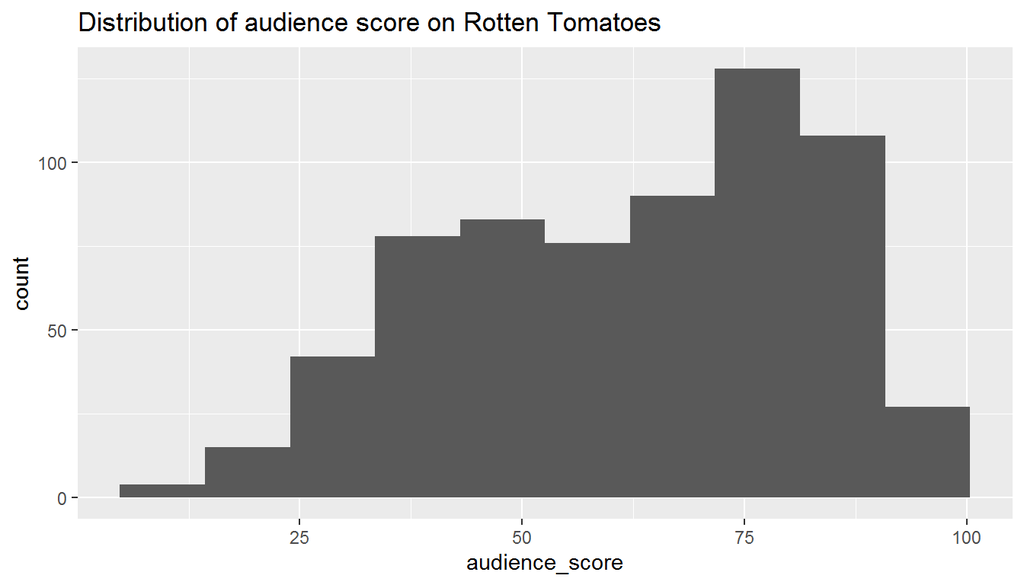

```r
movies %>%
    ggplot(aes(x = audience_score)) +
    geom_histogram(bins = 10) +
    ggtitle('Distribution of audience score on Rotten Tomatoes')
```

```r
summary(movies$audience_score)
```

```
##    Min. 1st Qu.  Median    Mean 3rd Qu.    Max.
##   11.00   46.00   65.00   62.36   80.00   97.00
```

Distribution of `audience_score` is also left-skewed with center around 65, hence the most appropriate measure of rating going to be median.

- Critics score on Rotten Tomatoes `critics_score`

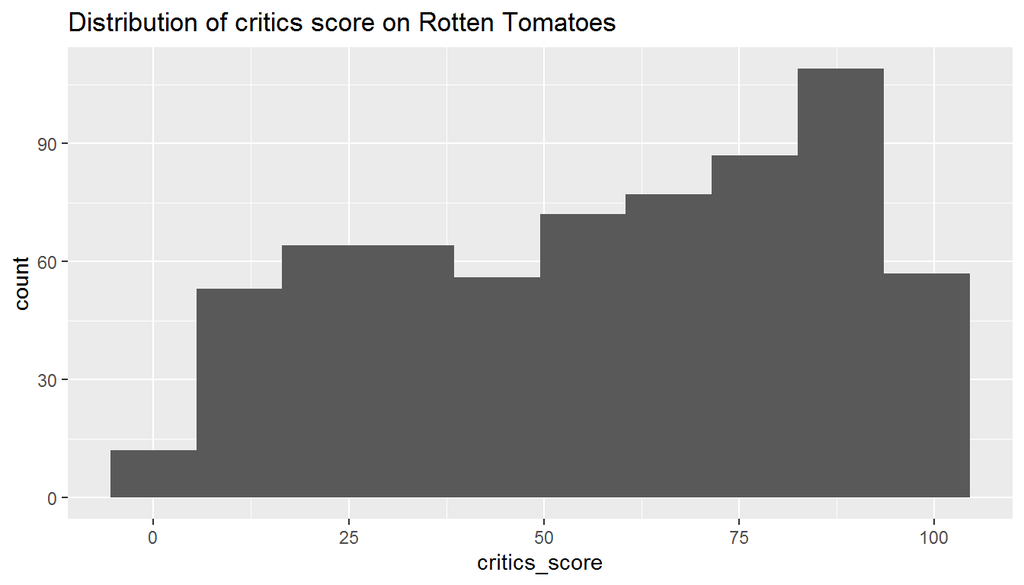

```r
movies %>%
    ggplot(aes(x = critics_score)) +
    geom_histogram(bins = 10) +
    ggtitle('Distribution of critics score on Rotten Tomatoes')
```

```r
summary(movies$critics_score)
```

```
##    Min. 1st Qu.  Median    Mean 3rd Qu.    Max.
##    1.00   33.00   61.00   57.69   83.00  100.00
```

Distribution of `audience_score` is also left-skewed with center around 61, hence the most appropriate measure of rating going to be median.

All of these distributions look roughly similar, probably, it would be a good idea to create an average rating score.

## Part 4: Modeling

### Predict variable

For our next step, let’s check collinearity of our ratings.

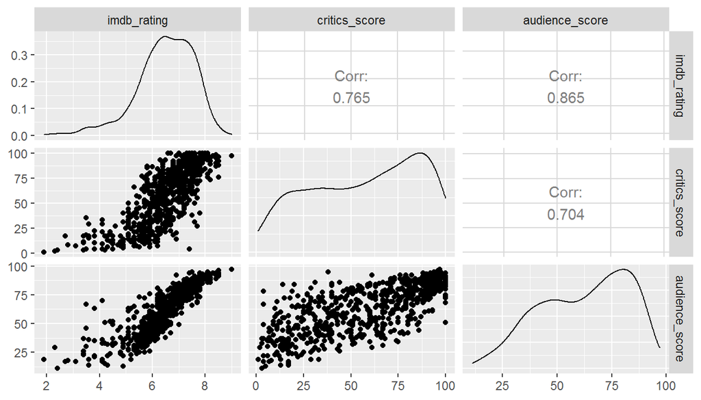

```r
ggpairs(movies, columns = c('imdb_rating', 'critics_score', 'audience_score'))
```

As aspected, they are collinear, but with it, we can find that Rating on IMDB and Audience score on Rotten Tomatoes is mush close to each other, on the other side Critics score has more differences. We going **create one average score**.

```r
movies <- movies %>%
  mutate(score_avg = (imdb_rating*10 + critics_score  + audience_score)/3)
```

### Checking conditions for explanatory variables

##### **Categorical variables**

Before we move on, let’s check conditions to have more or equal than 5 values in each group for using categorical explanatory variables.

**title_type** - all groups are good.

```r
movies %>%
  group_by(title_type) %>%
  summarise(n = n())
```

```
## # A tibble: 3 x 2
##   title_type       n
##   <fct>        <int>
## 1 Documentary     55
## 2 Feature Film   591
## 3 TV Movie         5
```

**genre** - all groups are good.

```r
movies %>%
  group_by(genre) %>%
  summarise(n = n())
```

```
## # A tibble: 11 x 2
##    genre                         n
##    <fct>                     <int>
##  1 Action & Adventure           65
##  2 Animation                     9
##  3 Art House & International    14
##  4 Comedy                       87
##  5 Documentary                  52
##  6 Drama                       305
##  7 Horror                       23
##  8 Musical & Performing Arts    12
##  9 Mystery & Suspense           59
## 10 Other                        16
## 11 Science Fiction & Fantasy     9
```

**mpaa_rating** - all groups are good, except “NC-17”. So, we should keep in our mind that if `mpaa_rating` gets into our final model and would be significant we must be very careful about making a prediction for that value.

```r
movies %>%
  group_by(mpaa_rating) %>%
  summarise(n = n())
```

```
## # A tibble: 6 x 2
##   mpaa_rating     n
##   <fct>       <int>
## 1 G              19
## 2 NC-17           2
## 3 PG            118
## 4 PG-13         133
## 5 R             329
## 6 Unrated        50
```

**studio** - Not good.

```r
movies %>%
  group_by(studio) %>%
  summarise(n = n())
```

```
## # A tibble: 212 x 2
##    studio                                n
##    <fct>                             <int>
##  1 20th Century Fox                     18
##  2 20th Century Fox Film Corporat        2
##  3 20th Century Fox Film Corporation     5
##  4 7-57 Releasing                        1
##  5 7th art                               1
##  6 905 Corporation                       1
##  7 A24                                   1
##  8 A24 Films                             2
##  9 All Girl Productions                  1
## 10 Alliance Atlantis Communications      1
## # ... with 202 more rows
```

For `studio` we got a lot of inappropriate groups. We should convert that variable.

```r
movies <- movies %>%
  mutate(studio_mod = case_when(studio == "20th Century Fox Film Corporat" ~ '20th Century Fox',
                                studio == "20th Century Fox Film Corporation" ~ '20th Century Fox',
                                studio == "A24" ~ 'A24 Films',
                                studio == "Buena Vista Distribution Compa" ~ 'Buena Vista',
                                studio == "Buena Vista Internationa" ~ 'Buena Vista',
                                studio == "Buena Vista Pictures" ~ 'Buena Vista',
                                studio == "Columbia Tristar Pictures" ~ 'Columbia Pictures',
                                studio == "Dreamworks" ~ 'DreamWorks Studios',
                                studio == "Fox" ~ '20th Century Fox',
                                studio == "Fox Atomic" ~ '20th Century Fox',
                                studio == "Fox Searchlight" ~ '20th Century Fox',
                                studio == "Fox Searchlight Pictures" ~ '20th Century Fox',
                                studio == "First Run Entertainment" ~ 'First Run Features',
                                studio == "HBO Documentary" ~ 'HBO',
                                studio == "HBO Video" ~ 'HBO',
                                studio == "IFC" ~ 'IFC Films',
                                studio == "IFC First Take" ~ 'IFC Films',
                                studio == "IFC Midnight" ~ 'IFC Films',
                                studio == "Lions Gate Films Inc." ~ 'Lions Gate Films',
                                studio == "Lions Gate Releasing" ~ 'Lions Gate Films',
                                studio == "Lionsgate" ~ 'Lions Gate Films',
                                studio == "LionsGate Entertainment" ~ 'Lions Gate Films',
                                studio == "Lions Gate Films Inc." ~ 'Lions Gate Films',
                                studio == "Lionsgate Films" ~ 'Lions Gate Films',
                                studio == "Lionsgate Releasing" ~ 'Lions Gate Films',
                                studio == "Magnet Releasing" ~ 'Magnolia Pictures',
                                studio == "Magnet/Magnolia Pictures" ~ 'Magnolia Pictures',
                                studio == "MGM Home Entertainment" ~ 'MGM',
                                studio == "MGM/UA" ~ 'MGM',
                                studio == "MGM/United Artists" ~ 'MGM',
                                studio == "Miramax" ~ 'Miramax Films',
                                studio == "National Geographic Entertainment" ~ 'National Geographic',
                                studio == "Orion Home Video" ~ 'Orion',
                                studio == "Orion Pictures" ~ 'Orion',
                                studio == "Orion Pictures Corporation" ~ 'Orion',
                                studio == "Paramount Classics" ~ 'Paramount Pictures',
                                studio == "Paramount" ~ 'Paramount Pictures',
                                studio == "Paramount Home Video" ~ 'Paramount Pictures',
                                studio == "Paramount Studios" ~ 'Paramount Pictures',
                                studio == "Paramount Vantage" ~ 'Paramount Pictures',
                                studio == "Sony Entertainment" ~ 'Sony Pictures',
                                studio == "Sony Pictures Classics" ~ 'Sony Pictures',
                                studio == "Sony Pictures Entertainment" ~ 'Sony Pictures',
                                studio == "Sony Pictures Home Entertainment" ~ 'Sony Pictures',
                                studio == "Sony Pictures/Columbia" ~ 'Sony Pictures',
                                studio == "Sony Pictures/Screen Gems" ~ 'Sony Pictures',
                                studio == "The Weinstein Co." ~ 'The Weinstein Company',
                                studio == "Touchstone Home Entertainment" ~ 'Touchstone Pictures',
                                studio == "TriStar" ~ 'Columbia Pictures',
                                studio == "TriStar Pictures" ~ 'Columbia Pictures',
                                studio == "Universal" ~ 'Universal Pictures',
                                studio == "Universal Studios" ~ 'Universal Pictures',
                                studio == "Walt Disney Home Entertainment" ~ 'Walt Disney Pictures',
                                studio == "Walt Disney Productions" ~ 'Walt Disney Pictures',
                                studio == "Disney" ~ 'Walt Disney Pictures',
                                studio == "Warner Bros Pictures" ~ 'Warner Bros. Pictures',
                                studio == "Warner Bros." ~ 'Warner Bros. Pictures',
                                studio == "WARNER BROTHERS PICTURES" ~ 'Warner Bros. Pictures',
                                studio == "Warner Home Video" ~ 'Warner Bros. Pictures',
                                studio == "Warner Independent" ~ 'Warner Bros. Pictures',
                                studio == "Warner Independent Pictures" ~ 'Warner Bros. Pictures',
                                studio == "Warners Bros. Pictures" ~ 'Warner Bros. Pictures',
                                studio == "Twentieth Century Fox Home Entertainment" ~ '20th Century Fox',
                                is.na(studio) ~ 'Others',
                                TRUE ~ as.character(studio)))

movies <- movies %>%
  group_by(studio_mod) %>%
  mutate(n = n()) %>%
  mutate(studio_mod2 = if_else(n < 5, 'Others', studio_mod))

movies %>%
  group_by(studio_mod2) %>%
  summarise(n = n())
```

```
## # A tibble: 23 x 2
##    studio_mod2                  n
##    <chr>                    <int>
##  1 20th Century Fox            51
##  2 Buena Vista                 18
##  3 Columbia Pictures           11
##  4 First Run Features           7
##  5 HBO                          9
##  6 IFC Films                   18
##  7 Lions Gate Films            20
##  8 Magnolia Pictures           11
##  9 MCA Universal Home Video    13
## 10 MGM                         27
## # ... with 13 more rows
```

Finally, we got **`studio_mod2`, where all groups are good.**

**best_pic_nom** - all groups are good.

```r
movies %>%
  group_by(best_pic_nom) %>%
  summarise(n = n())
```

```
## # A tibble: 2 x 2
##   best_pic_nom     n
##   <fct>        <int>
## 1 no             629
## 2 yes             22
```

**best_pic_win** - all groups are good.

```r
movies %>%
  group_by(best_pic_win) %>%
  summarise(n = n())
```

```
## # A tibble: 2 x 2
##   best_pic_win     n
##   <fct>        <int>
## 1 no             644
## 2 yes              7
```

**best_actor_win** - all groups are good.

```r
movies %>%
  group_by(best_actor_win) %>%
  summarise(n = n())
```

```
## # A tibble: 2 x 2
##   best_actor_win     n
##   <fct>          <int>
## 1 no               558
## 2 yes               93
```

**best_actress_win** - all groups are good.

```r
movies %>%
  group_by(best_actress_win) %>%
  summarise(n = n())
```

```
## # A tibble: 2 x 2
##   best_actress_win     n
##   <fct>            <int>
## 1 no                 579
## 2 yes                 72
```

**best_dir_win** - all groups are good.

```r
movies %>%
  group_by(best_dir_win) %>%
  summarise(n = n())
```

```
## # A tibble: 2 x 2
##   best_dir_win     n
##   <fct>        <int>
## 1 no             608
## 2 yes             43
```

##### **Numerical variables**

Now let’s check numerical explanatory variables.

**runtime** - not good.

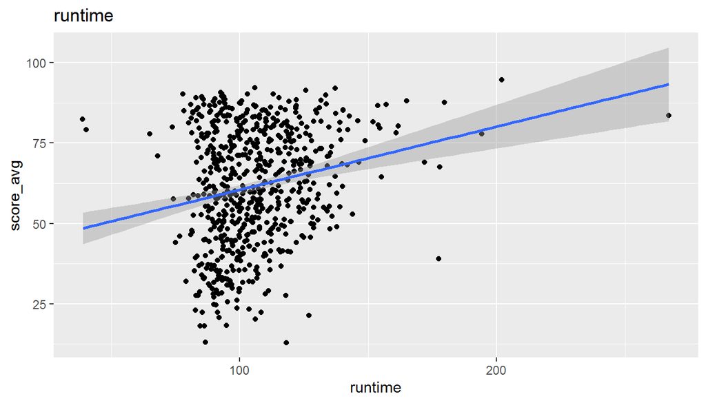

```r
movies %>%
  filter(!is.na(runtime)) %>%
  ggplot(aes(x = runtime, y = score_avg)) +
  geom_jitter() +
  geom_smooth(method = "lm") +
  ggtitle('runtime')
```

The plot doesn’t show us a clean relationship between `runtime` and `score_avg`. Probably, we get so trend because of the influential point above 250 minutes. We shouldn’t use `runtime` in our prediction model.

**thtr_rel_year** - not good.

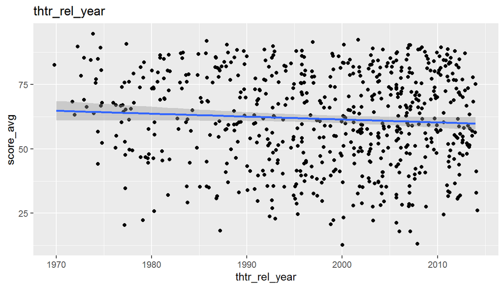

```r
movies %>%
  ggplot(aes(x = thtr_rel_year, y = score_avg)) +
  geom_jitter() +
  geom_smooth(method = "lm") +
  ggtitle('thtr_rel_year')
```

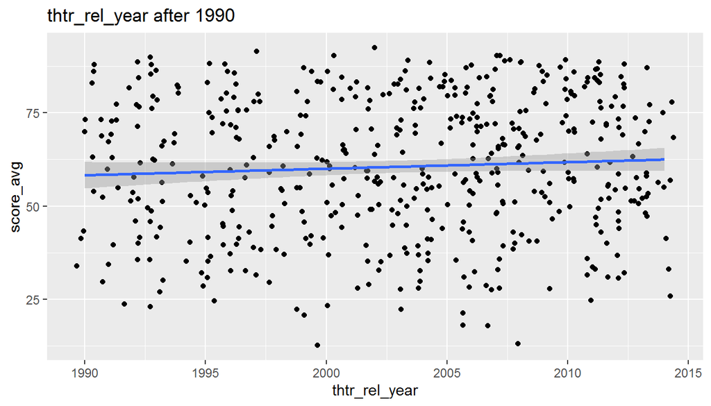

```r
movies %>%
  filter(thtr_rel_year >= 1990) %>%
  ggplot(aes(x = thtr_rel_year, y = score_avg)) +
  geom_jitter() +
  geom_smooth(method = "lm") +
  ggtitle('thtr_rel_year after 1990')
```

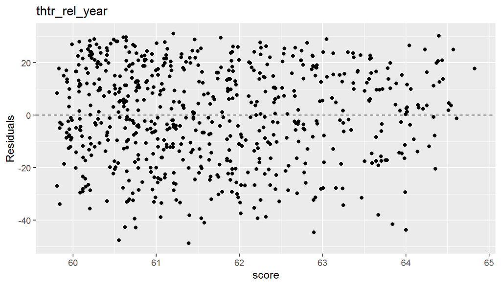

```r
m <- lm(score_avg ~ thtr_rel_year, data = movies)

m %>%
  ggplot(aes(x = .fitted, y = .resid)) +
  geom_jitter() +
  geom_hline(yintercept = 0, linetype = "dashed") +
  xlab("score") +
  ylab("Residuals") +
  ggtitle('thtr_rel_year')
```

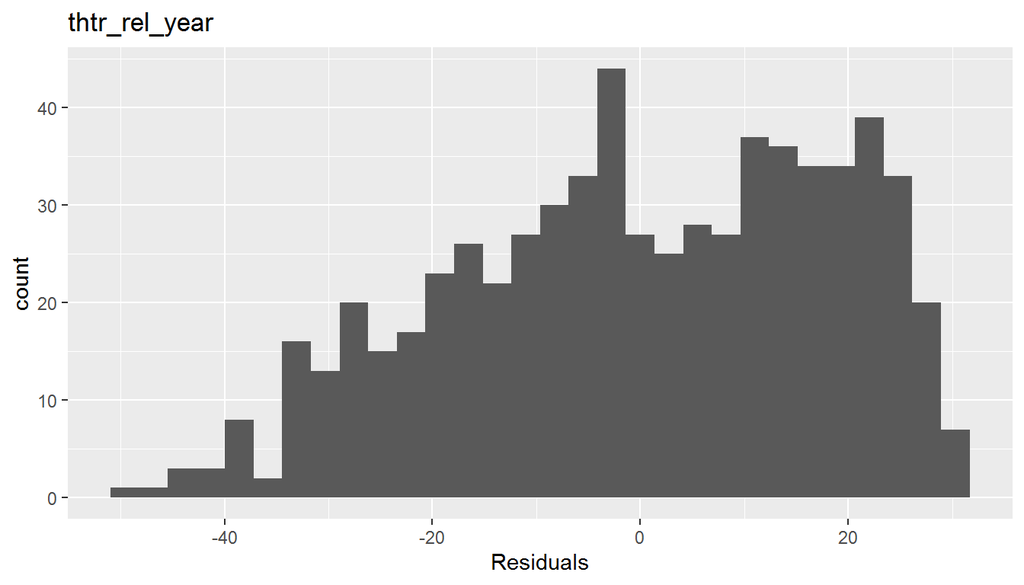

```r
m %>%
  ggplot(aes(x = .resid)) +
  geom_histogram(bins = 30) +
  xlab("Residuals") +
  ggtitle('thtr_rel_year')
```

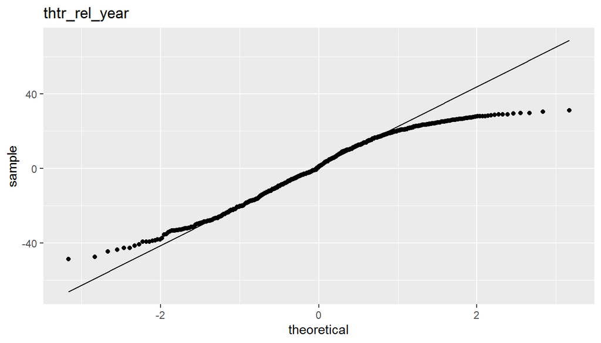

```r
m %>%
  ggplot(aes(sample = .resid)) +
  stat_qq() +
  stat_qq_line() +
  ggtitle('thtr_rel_year')
```

```r
summary(m)
```

```
##
## Call:
## lm(formula = score_avg ~ thtr_rel_year, data = movies)
##
## Residuals:
##     Min      1Q  Median      3Q     Max
## -48.762 -13.092   0.905  15.657  31.131
##
## Coefficients:
##                Estimate Std. Error t value Pr(>|t|)
## (Intercept)   287.01806  130.02595   2.207   0.0276 *
## thtr_rel_year  -0.11279    0.06508  -1.733   0.0835 .
## ---
## Signif. codes:  0 '***' 0.001 '**' 0.01 '*' 0.05 '.' 0.1 ' ' 1
##
## Residual standard error: 18.21 on 649 degrees of freedom
## Multiple R-squared:  0.004607,   Adjusted R-squared:  0.003074
## F-statistic: 3.004 on 1 and 649 DF,  p-value: 0.08354
```

Plots show us unclear relationship between `thtr_rel_year` and `score_avg`. Also, we can see different trend direction if we use all data (negative) and data after 1990 (positive). At the same time residuals distribution are left-skewed. Considering all this we should not use `thtr_rel_year` in our predict model.

**dvd_rel_year** - not good.

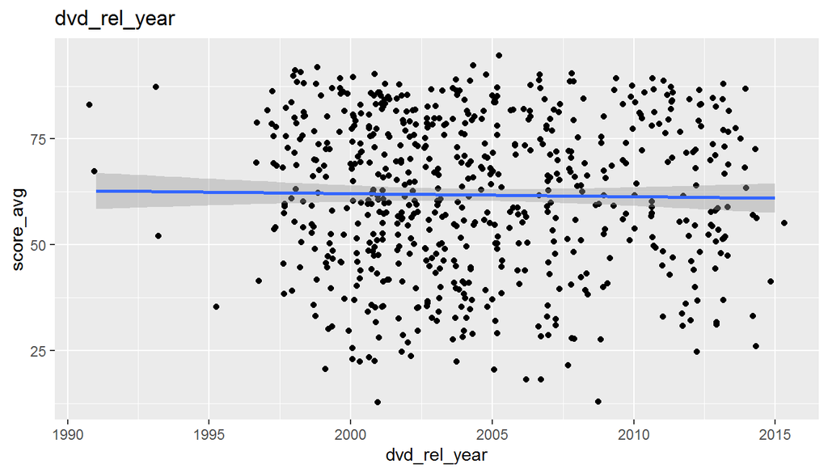

```r
movies %>%
  filter(!is.na(dvd_rel_year)) %>%
  ggplot(aes(x = dvd_rel_year, y = score_avg)) +
  geom_jitter() +
  geom_smooth(method = "lm") +
  ggtitle('dvd_rel_year')
```

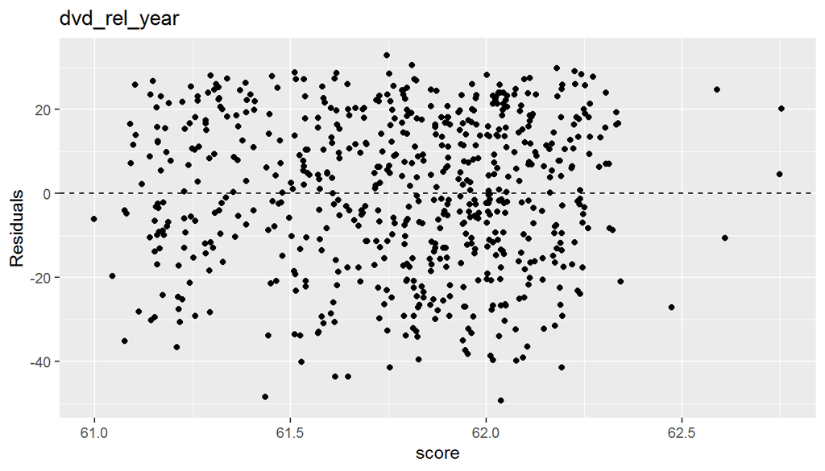

```r
m <- lm(score_avg ~ dvd_rel_year, data = movies)

m %>%
  ggplot(aes(x = .fitted, y = .resid)) +
  geom_jitter() +
  geom_hline(yintercept = 0, linetype = "dashed") +
  xlab("score") +
  ylab("Residuals") +
  ggtitle('dvd_rel_year')
```

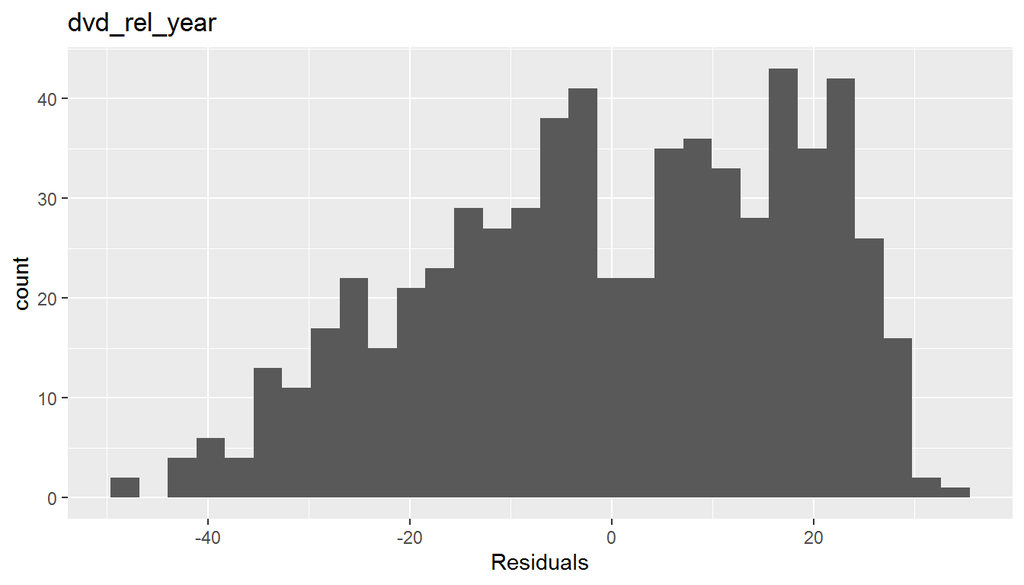

```r
m %>%
  ggplot(aes(x = .resid)) +
  geom_histogram(bins = 30) +
  xlab("Residuals") +
  ggtitle('dvd_rel_year')
```

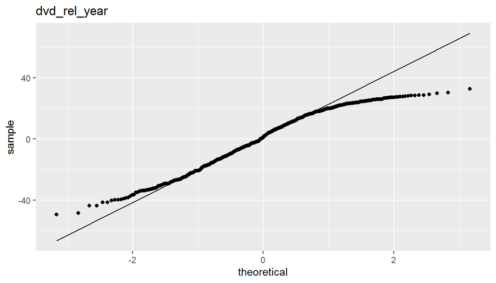

```r
m %>%
  ggplot(aes(sample = .resid)) +
  stat_qq() +
  stat_qq_line() +
  ggtitle('dvd_rel_year')
```

```r
summary(m)
```

```
##
## Call:
## lm(formula = score_avg ~ dvd_rel_year, data = movies)
##
## Residuals:
##    Min     1Q Median     3Q    Max
## -49.36 -13.17   1.07  15.81  32.93
##
## Coefficients:
##               Estimate Std. Error t value Pr(>|t|)
## (Intercept)  205.75178  309.17429   0.665    0.506
## dvd_rel_year  -0.07183    0.15425  -0.466    0.642
##
## Residual standard error: 18.15 on 641 degrees of freedom
##   (8 observations deleted due to missingness)
## Multiple R-squared:  0.0003382,  Adjusted R-squared:  -0.001221
## F-statistic: 0.2168 on 1 and 641 DF,  p-value: 0.6416
```

Here we get roughly the same picture that `thtr_rel_year` does.

**thtr_rel_month** - not good.

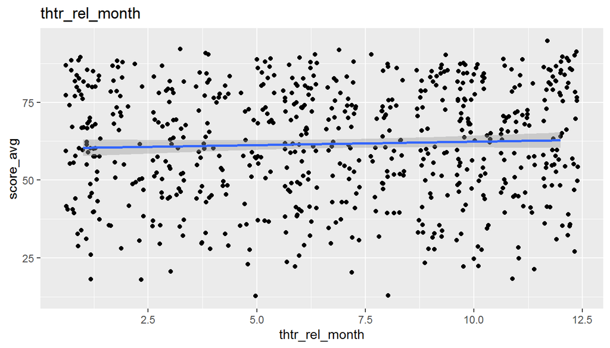

```r
movies %>%
  ggplot(aes(x = thtr_rel_month, y = score_avg)) +
  geom_jitter() +
  geom_smooth(method = "lm") +
  ggtitle('thtr_rel_month')
```

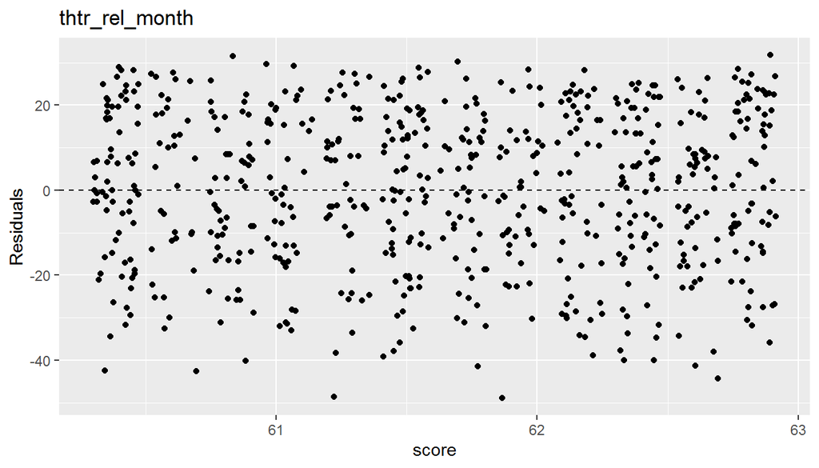

```r
m <- lm(score_avg ~ thtr_rel_month, data = movies)

m %>%
  ggplot(aes(x = .fitted, y = .resid)) +
  geom_jitter() +
  geom_hline(yintercept = 0, linetype = "dashed") +
  xlab("score") +
  ylab("Residuals") +
  ggtitle('thtr_rel_month')
```

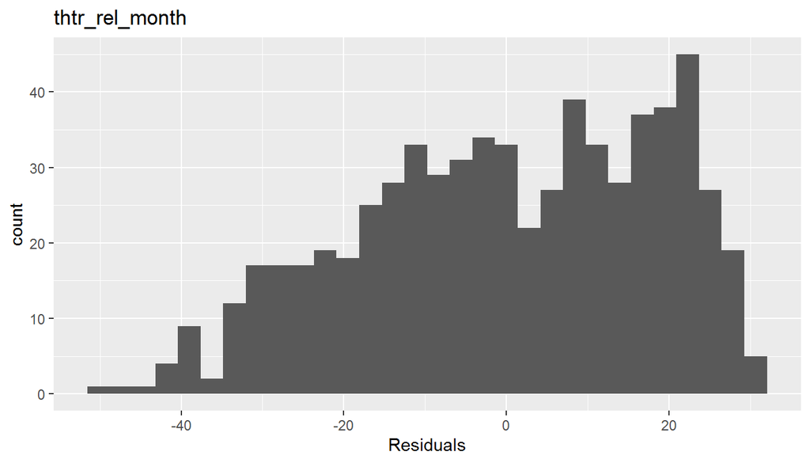

```r
m %>%
  ggplot(aes(x = .resid)) +
  geom_histogram(bins = 30) +
  xlab("Residuals") +
  ggtitle('thtr_rel_month')
```

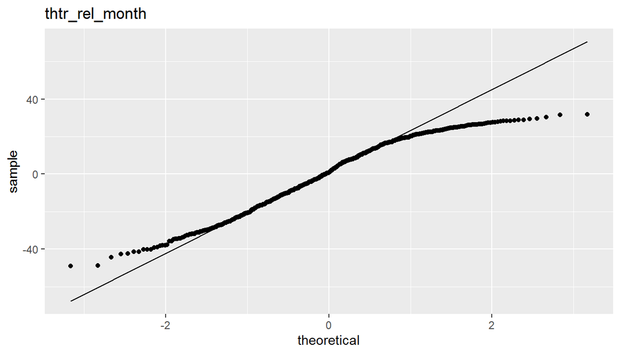

```r
m %>%
  ggplot(aes(sample = .resid)) +
  stat_qq() +
  stat_qq_line() +
  ggtitle('thtr_rel_month')
```

```r
summary(m)
```

```
##
## Call:
## lm(formula = score_avg ~ thtr_rel_month, data = movies)
##
## Residuals:
##     Min      1Q  Median      3Q     Max
## -48.940 -13.272   0.836  16.173  31.839
##
## Coefficients:
##                Estimate Std. Error t value Pr(>|t|)
## (Intercept)     60.1652     1.5331  39.245   <2e-16 ***
## thtr_rel_month   0.2218     0.2012   1.103    0.271
## ---
## Signif. codes:  0 '***' 0.001 '**' 0.01 '*' 0.05 '.' 0.1 ' ' 1
##
## Residual standard error: 18.23 on 649 degrees of freedom
## Multiple R-squared:  0.001869,   Adjusted R-squared:  0.0003314
## F-statistic: 1.216 on 1 and 649 DF,  p-value: 0.2707
```

Plots show us unclear relationship between `thtr_rel_month` and `score_avg`. At the same time residuals distribution are left-skewed. Considering all this we should not use `thtr_rel_month` in our predict model.

**dvd_rel_month** - not good.

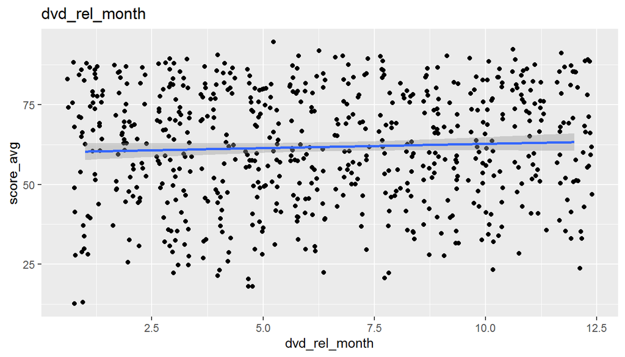

```r
movies %>%
  filter(!is.na(dvd_rel_month)) %>%
  ggplot(aes(x = dvd_rel_month, y = score_avg)) +
  geom_jitter() +
  geom_smooth(method = "lm") +
  ggtitle('dvd_rel_month')
```

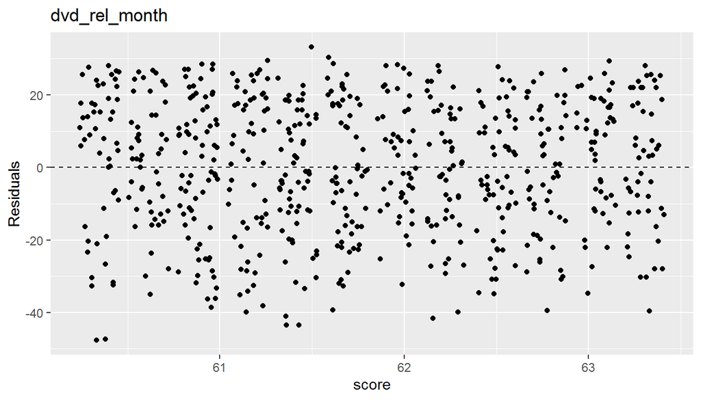

```r
m <- lm(score_avg ~ dvd_rel_month, data = movies)

m %>%
  ggplot(aes(x = .fitted, y = .resid)) +
  geom_jitter() +
  geom_hline(yintercept = 0, linetype = "dashed") +
  xlab("score") +
  ylab("Residuals") +
  ggtitle('dvd_rel_month')
```

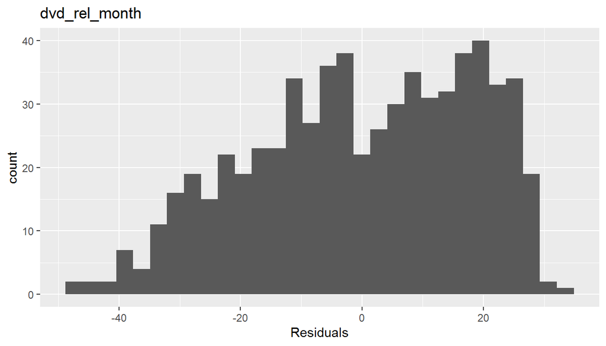

```r
m %>%
  ggplot(aes(x = .resid)) +
  geom_histogram(bins = 30) +
  xlab("Residuals") +
  ggtitle('dvd_rel_month')
```

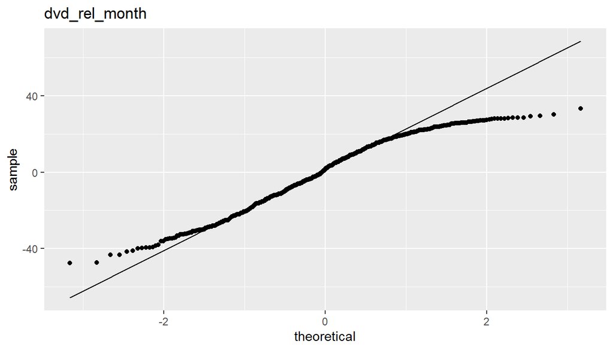

```r
m %>%
  ggplot(aes(sample = .resid)) +
  stat_qq() +
  stat_qq_line() +
  ggtitle('dvd_rel_month')
```

```r
summary(m)
```

```
##
## Call:
## lm(formula = score_avg ~ dvd_rel_month, data = movies)
##
## Residuals:
##     Min      1Q  Median      3Q     Max
## -47.678 -12.915   1.244  15.776  33.244
##
## Coefficients:
##               Estimate Std. Error t value Pr(>|t|)
## (Intercept)    60.0749     1.5199  39.527   <2e-16 ***
## dvd_rel_month   0.2695     0.2118   1.273    0.204
## ---
## Signif. codes:  0 '***' 0.001 '**' 0.01 '*' 0.05 '.' 0.1 ' ' 1
##
## Residual standard error: 18.13 on 641 degrees of freedom
##   (8 observations deleted due to missingness)
## Multiple R-squared:  0.00252,    Adjusted R-squared:  0.000964
## F-statistic: 1.619 on 1 and 641 DF,  p-value: 0.2036
```

Roughly the same picture that `thtr_rel_month` does.

**dvd_rel_day** - not good.

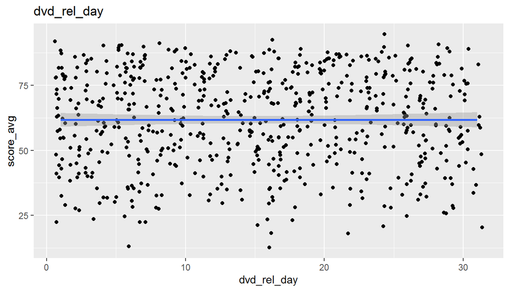

```r
movies %>%
  filter(!is.na(dvd_rel_day)) %>%
  ggplot(aes(x = dvd_rel_day, y = score_avg)) +
  geom_jitter() +
  geom_smooth(method = "lm") +
  ggtitle('dvd_rel_day')
```

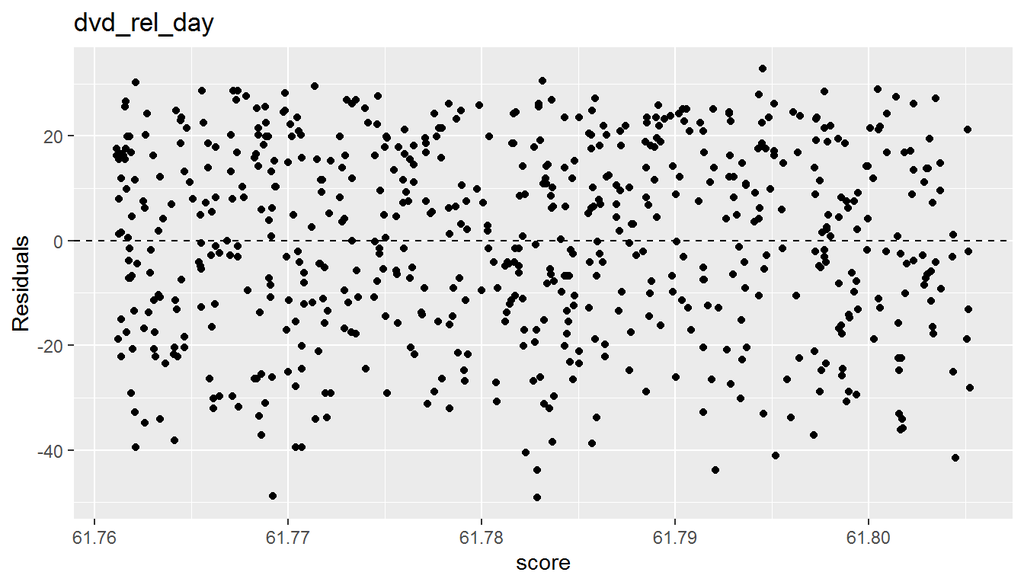

```r
m <- lm(score_avg ~ dvd_rel_day, data = movies)

m %>%
  ggplot(aes(x = .fitted, y = .resid)) +
  geom_jitter() +
  geom_hline(yintercept = 0, linetype = "dashed") +
  xlab("score") +
  ylab("Residuals") +
  ggtitle('dvd_rel_day')
```

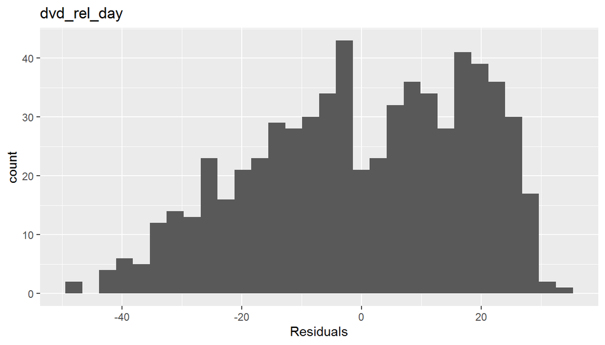

```r
m %>%
  ggplot(aes(x = .resid)) +
  geom_histogram(bins = 30) +
  xlab("Residuals") +
  ggtitle('dvd_rel_day')
```

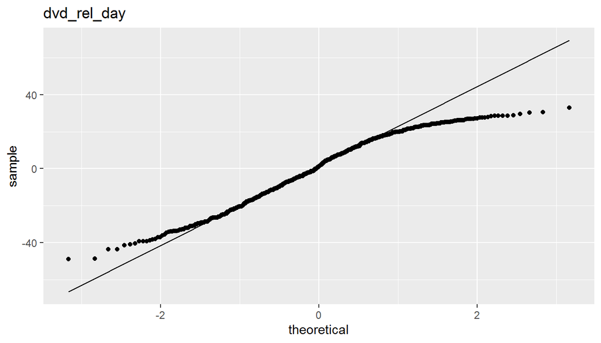

```r
m %>%
  ggplot(aes(sample = .resid)) +
  stat_qq() +
  stat_qq_line() +
  ggtitle('dvd_rel_day')
```

```r
summary(m)
```

```
##
## Call:
## lm(formula = score_avg ~ dvd_rel_day, data = movies)
##
## Residuals:
##     Min      1Q  Median      3Q     Max
## -49.117 -13.135   1.195  15.893  32.872
##
## Coefficients:
##              Estimate Std. Error t value Pr(>|t|)
## (Intercept) 61.760221   1.407975  43.865   <2e-16 ***
## dvd_rel_day  0.001435   0.080787   0.018    0.986
## ---
## Signif. codes:  0 '***' 0.001 '**' 0.01 '*' 0.05 '.' 0.1 ' ' 1
##
## Residual standard error: 18.15 on 641 degrees of freedom
##   (8 observations deleted due to missingness)
## Multiple R-squared:  4.92e-07,   Adjusted R-squared:  -0.00156
## F-statistic: 0.0003154 on 1 and 641 DF,  p-value: 0.9858
```

Plots show us unclear relationship between `dvd_rel_day` and `score_avg`. At the same time residuals distribution are left-skewed. Considering all this we should not use `dvd_rel_day` in our predict model.

**thtr_rel_day** - not good.

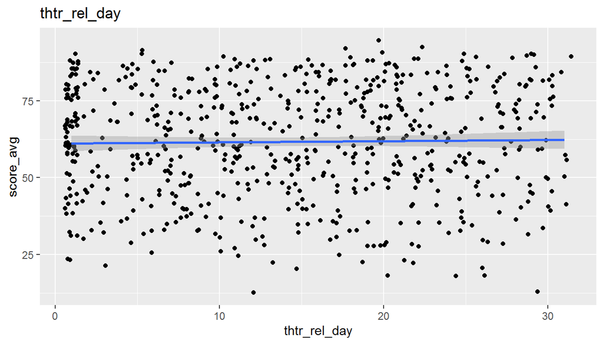

```r
movies %>%
  filter(!is.na(thtr_rel_day)) %>%
  ggplot(aes(x = thtr_rel_day, y = score_avg)) +
  geom_jitter() +
  geom_smooth(method = "lm") +
  ggtitle('thtr_rel_day')
```

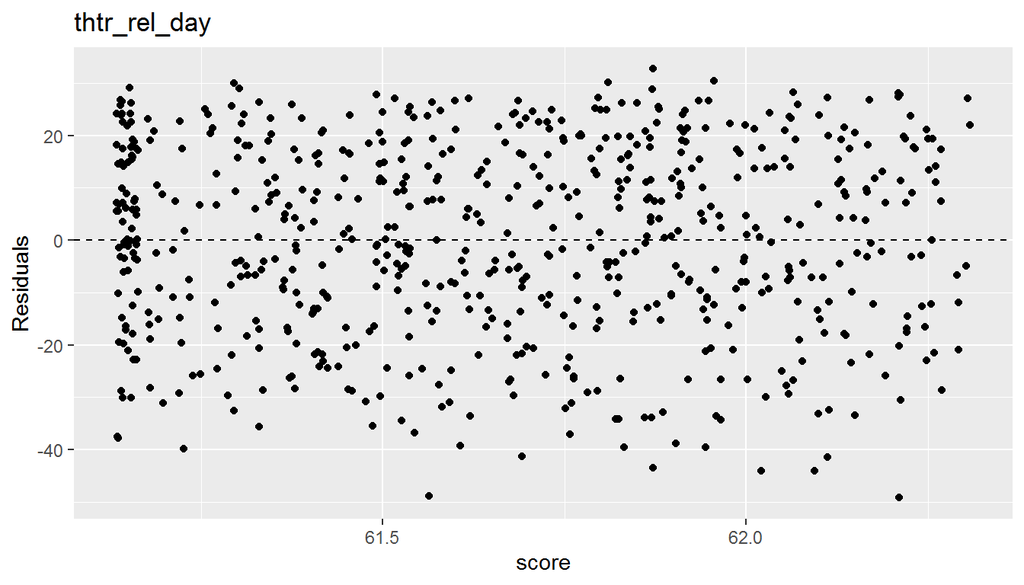

```r
m <- lm(score_avg ~ thtr_rel_day, data = movies)

m %>%
  ggplot(aes(x = .fitted, y = .resid)) +
  geom_jitter() +
  geom_hline(yintercept = 0, linetype = "dashed") +
  xlab("score") +
  ylab("Residuals") +
  ggtitle('thtr_rel_day')
```

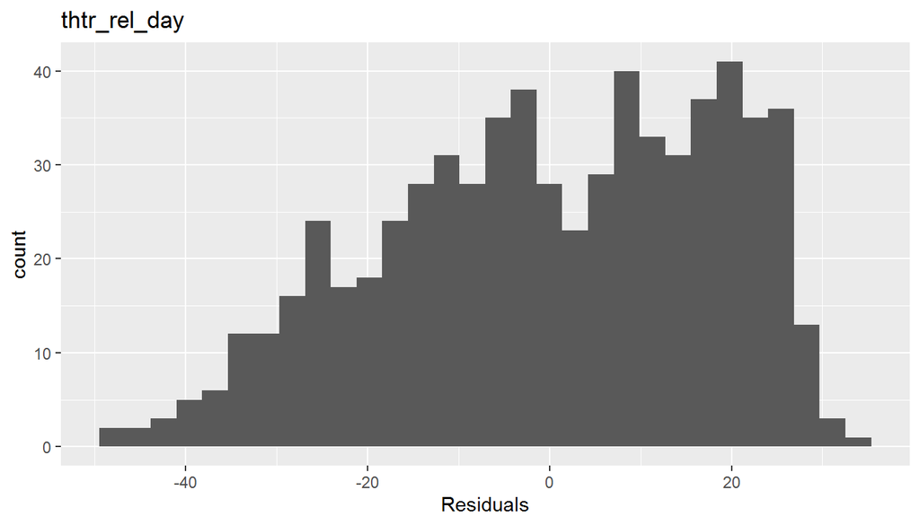

```r
m %>%
  ggplot(aes(x = .resid)) +
  geom_histogram(bins = 30) +
  xlab("Residuals") +
  ggtitle('thtr_rel_day')
```

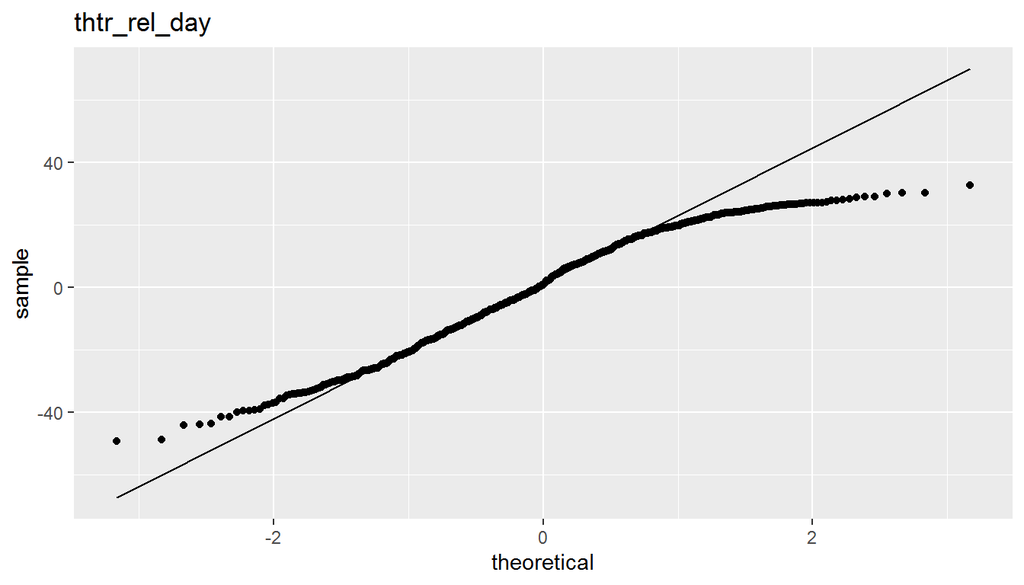

```r
m %>%
  ggplot(aes(sample = .resid)) +
  stat_qq() +
  stat_qq_line() +
  ggtitle('thtr_rel_day')
```

```r
summary(m)
```

```
##
## Call:
## lm(formula = score_avg ~ thtr_rel_day, data = movies)
##
## Residuals:
##     Min      1Q  Median      3Q     Max
## -49.217 -13.278   0.793  16.008  32.793
##
## Coefficients:
##              Estimate Std. Error t value Pr(>|t|)
## (Intercept)  61.11010    1.36653  44.719   <2e-16 ***
## thtr_rel_day  0.03818    0.08077   0.473    0.637
## ---
## Signif. codes:  0 '***' 0.001 '**' 0.01 '*' 0.05 '.' 0.1 ' ' 1
##
## Residual standard error: 18.25 on 649 degrees of freedom
## Multiple R-squared:  0.0003442,  Adjusted R-squared:  -0.001196
## F-statistic: 0.2234 on 1 and 649 DF,  p-value: 0.6366
```

Roughly the same picture that `dvd_rel_day` does.